# 课后作业：Python机器学习环境的安装和配置

**【作业提交】**

将分类结果保存到文本文档进行提交，同时提交源代码。

1. 测试结果命名为: ex01-结果图01-你的学号-你的姓名.png, ex01-结果图02-你的学号-你的姓名.png
2. 源代码命名为: ex01-01-你的学号-你的姓名.py, ex01-02-你的学号-你的姓名.py, ex01-03-你的学号-你的姓名.py

*结果文件，要求每小题标注题号，两题之间要求空一行*

要求完成以下几个作业：

- 利用pandas库和字典完成以下习题（ex01-01）
- 利用matplotlib库绘制如下图（1）使用代码生成一个表达式为：$y=2x^2-3x^4+6x-3$ 的曲线图。（ex01-02）
- 利用matplotlib库绘制如下图（2）生成直方图（ex01-03）

#### 一. 利用pandas库和字典完成以下习题

1. 生成如下表格

```python
# 使用import关键字引入pandas库，为了简便使用缩写 “pd”来表示pandas库。
import pandas as pd

# 使用字典数据类型创建一个数据表，并用pandas库的DataFrame数据结构进行显示
data = {"姓名":["拿破仑","哥德巴赫","秦始皇","凯撒","耶稣"],
        "国家":["地球联盟","黑暗祭祀","地球联盟","黑暗祭祀","地球联盟"],
        "学号":["2019001","2019002","2019003","2019004","2019005"],
        "语文":[33,28,32,30,99],
        "数学":[98,97,94,92,100] ,
        "英语":[33,28,32,30,97],
        "科学":[98,97,94,92,98],
        "历史":[94,57,96,98,91]
}
data_frame = pd.DataFrame(data)
display(data_frame)
```

|  | 姓名 | 国家 | 学号 | 语文 | 数学 | 英语 | 科学 | 历史 |
| --- | --- | --- | --- | --- | --- | --- | --- | --- |
| 0 | 拿破仑 | 地球联盟 | 2019001 | 33 | 98 | 33 | 98 | 94 |
| 1 | 哥德巴赫 | 黑暗祭祀 | 2019002 | 28 | 97 | 28 | 97 | 57 |
| 2 | 秦始皇 | 地球联盟 | 2019003 | 32 | 94 | 32 | 94 | 96 |
| 3 | 凯撒 | 黑暗祭祀 | 2019004 | 30 | 92 | 30 | 92 | 98 |
| 4 | 耶稣 | 地球联盟 | 2019005 | 99 | 100 | 97 | 98 | 91 |

1. 通过对表格的操作，获得以下几个结果

(1) 获取国家不等于“地球联盟”的数据

```python
# 使用 “不等于 !=” 操作符排除字段中包含特定值的数据
display(data_frame[data_frame.国家 != "地球联盟"])
```

|  | 姓名 | 国家 | 学号 | 语文 | 数学 | 英语 | 科学 | 历史 |
| --- | --- | --- | --- | --- | --- | --- | --- | --- |
| 1 | 哥德巴赫 | 黑暗祭祀 | 2019002 | 28 | 97 | 28 | 97 | 57 |
| 3 | 凯撒 | 黑暗祭祀 | 2019004 | 30 | 92 | 30 | 92 | 98 |

(2) 获取学号等于2019003的数据

```python
display(data_frame[data_frame.学号 == "2019003"])
```

|  | 姓名 | 国家 | 学号 | 语文 | 数学 | 英语 | 科学 | 历史 |
| --- | --- | --- | --- | --- | --- | --- | --- | --- |
| 2 | 秦始皇 | 地球联盟 | 2019003 | 32 | 94 | 32 | 94 | 96 |

(3)获取数学成绩大于95的同学的数据

```python
display(data_frame[data_frame.数学 > 95])
```

|  | 姓名 | 国家 | 学号 | 语文 | 数学 | 英语 | 科学 | 历史 |
| --- | --- | --- | --- | --- | --- | --- | --- | --- |
| 0 | 拿破仑 | 地球联盟 | 2019001 | 33 | 98 | 33 | 98 | 94 |
| 1 | 哥德巴赫 | 黑暗祭祀 | 2019002 | 28 | 97 | 28 | 97 | 57 |
| 4 | 耶稣 | 地球联盟 | 2019005 | 99 | 100 | 97 | 98 | 91 |

(4) 获取历史成绩大于60，同时属于“黑暗祭祀”的同学的信息

```python
display(data_frame[(data_frame.历史 > 60) & (data_frame.国家 == "黑暗祭祀")])
```

|  | 姓名 | 国家 | 学号 | 语文 | 数学 | 英语 | 科学 | 历史 |
| --- | --- | --- | --- | --- | --- | --- | --- | --- |
| 3 | 凯撒 | 黑暗祭祀 | 2019004 | 30 | 92 | 30 | 92 | 98 |

```python
(data_frame.历史 > 60) & (data_frame.国家 == "黑暗祭祀")
```

```
0    False
1    False
2    False
3     True
4    False
dtype: bool
```

#### 二. 利用matplotlib库绘制如下图

1. 使用代码生成一个表达式为：$y=2x^2-3x^4+6x-3$ 的曲线图。

自变量x的取值范围为：(-20, 20, 10)

对于取值范围有两种理解：

- np.arange(-20, 20, 10) 起点-20，终点20，步长为10
- np.linspace(-20, 20 ,10) 起点-20，终点20，生成10个元素的等差数列

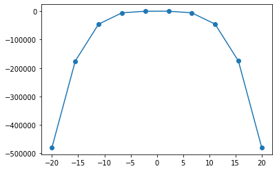

```python
# 通过inline指令，实现在Jupyter中的实时绘图功能
%matplotlib inline

# 1. 引入库
# 使用import关键字引入matplotlib库，为了简便使用缩写 “plt”来表示matplotlib库。
import matplotlib.pyplot as plt
import numpy as np

# 2. 指定坐标轴（x,y值）
# 使用linspace()函数生成一个-20到20，元素个数为10的等差数列。
# 令数列中的值为 x, 并根据表达式计算对应的 y值。
x = np.linspace(-20, 20, 10)
y = 2*x**2 - 3*x**4 + 6*x - 3

# 3. 把x,y的关系画到坐标轴上 plot(横坐标，纵坐标，标记，颜色。。。。)
#使用plot()函数绘制出曲线图
plt.plot(x, y, marker = "o")
plt.show()
```

1. 生成直方图

直方图应包含6个序列，每个序列3种类型的特征，取值如下：

```
x_data = ('China', 'America', 'Japan', 'Germany', 'France', 'Italy')
y1_data = (120, 325, 310, 235, 227, 256)
y2_data = (225, 312, 314, 221, 253, 341)
y3_data = (232, 332, 222, 241, 190, 299)
```

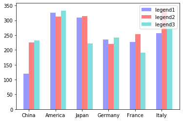

```python
# 通过inline指令，实现在Jupyter中的实时绘图功能
%matplotlib inline
import matplotlib.pyplot as plt
import numpy as np

plt.figure(1)
x_index = np.arange(6)   #柱的索引
x_data = ('China', 'America', 'Japan', 'Germany', 'France', 'Italy')
y1_data = (120, 325, 310, 235, 227, 256)
y2_data = (225, 312, 314, 221, 253, 341)
y3_data = (232, 332, 222, 241, 190, 299)
bar_width = 0.2  #定义一个数字代表每个独立柱的宽度

# 使用 bar()函数定义柱状图的各个参数，依次包括：左偏移、高度、柱宽、透明度、颜色、图例
# 关于左偏移，不用关心每根柱的中心不中心，因为只要把刻度线设置在柱的中间就可以了
rects1 = plt.bar(x_index, y1_data, width=bar_width,alpha=0.4, color='b',label='legend1')
rects2 = plt.bar(x_index + bar_width, y2_data, width=bar_width,alpha=0.5,color='r',label='legend2')
rects3 = plt.bar(x_index + bar_width + bar_width, y3_data, width=bar_width,alpha=0.5,color='c',label='legend3')

# 使用 xticks() 函数设置x轴的刻度线
plt.xticks(x_index + bar_width/2, x_data)
plt.legend() #显示图例
plt.show()
```